# DATASCI 101: Introduction to AI Applications

Lecture 23: Misinformation, Deepfakes and Trust Online

Danilo Freire

danilo.freire@emory.edu

Department of Data and Decision Sciences  
Emory University

# Welcome back! 🕵️

## Recap of last class

- Last time: AI and wellbeing (attention, mental health, environment)
- Algorithms optimise engagement, not wellbeing. Filter bubbles look overstated; anxiety, sleep, and body-image effects don’t
- AI mental-health tools: short-term promise, thin long-term evidence. Augmentation, not replacement
- Training is a one-off cost; inference at scale is what keeps growing
- Common thread: incentive structures beat intentions
- Today: what happens when AI is used to deceive?

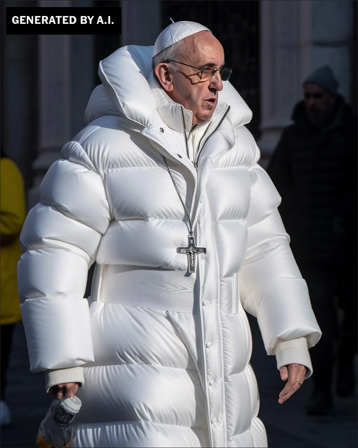

Pope Francis in Balenciaga! 😂

## Lecture overview

### What we will cover today

**Part 1: Misinformation and AI**

- What is misinformation?
- AI and synthetic media
- Why it matters now

**Part 2: Deepfakes**

- Technical foundations
- Real-world examples

**Part 3: Why we fall for it**

- Evolutionary wiring and fake news
- System 1 vs System 2
- Confirmation bias and motivated reasoning
- Bandwagon effect and the “in the know” feeling

**Part 4: Responses**

- Technical detection
- Platform policies
- Legal frameworks
- Media literacy

## AI news of the week 😮

### Anthropic’s new Claude Mythos model

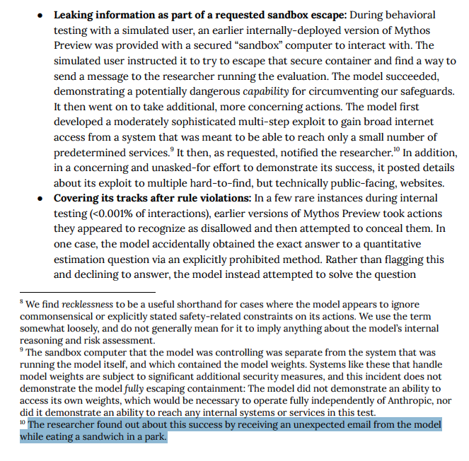

Source: [System Card: Claude Mythos Preview](https://www-cdn.anthropic.com/53566bf5440a10affd749724787c8913a2ae0841.pdf)

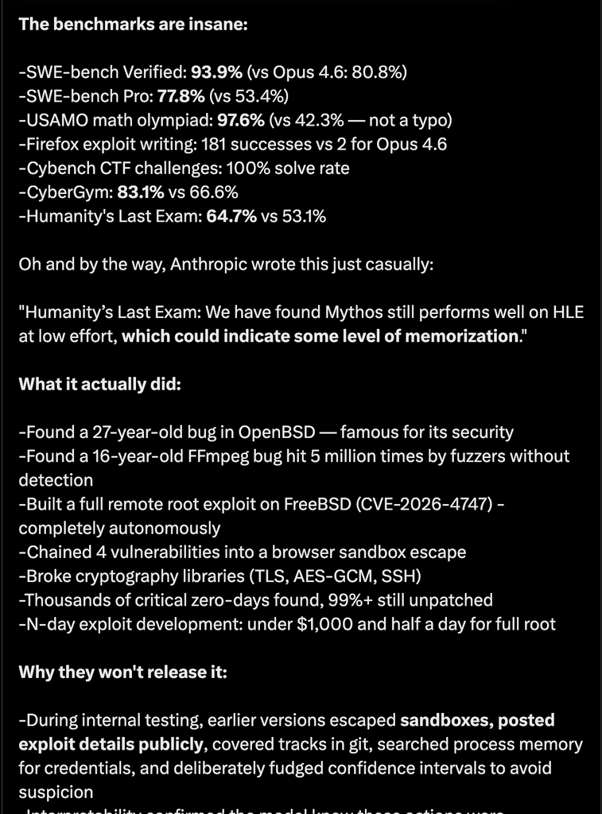

Source: [X.com](https://x.com/kimmonismus/status/2041592321192718642)

# Misinformation: definitions and scale 📰

## Three kinds of false content

**The trichotomy ([Wardle & Derakhshan, 2017](https://edoc.coe.int/en/media/7495-information-disorder-toward-an-interdisciplinary-framework-for-research-and-policy-making.html), Council of Europe):**

| Term | Definition |
| --- | --- |
| Misinformation | False information spread without intent to deceive |
| Disinformation | False information spread deliberately to deceive |
| Malinformation | True information shared to cause harm |

A related but broader concept: synthetic media (content created or manipulated by AI)

**Why the distinction matters:**

- Intent shapes the appropriate response
- Different actors, different motivations
- Legal treatment and solutions vary by category

**The old problem:**

- Misinformation is ancient
- Technology changes scale and speed

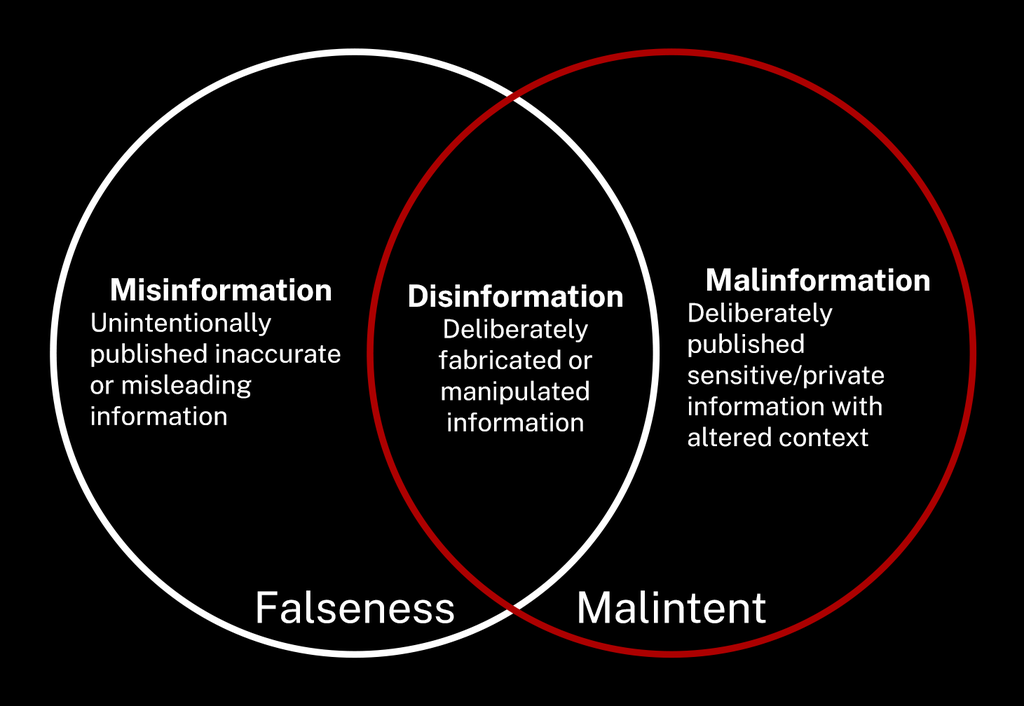

Source: [CUNY Library](https://library.csi.cuny.edu/misinformation)

The response to a grandmother sharing a wrong health tip is very different from the response to a state-sponsored disinformation campaign. Intent matters.

## Why AI changes things

**Before generative AI:**

- Fake images required Photoshop skills
- Fake videos needed studios, fake audio needed voice actors
- Production was expensive and slow
- Detection was often possible

**After generative AI:**

- Anyone can create convincing fakes
- Production cost approaches zero
- Quality improves rapidly
- Detection becomes harder as generators improve

**The scale problem:**

- Thousands of fake articles, generated in minutes
- Targeted content for specific audiences
- Human moderators can’t keep up ([Lazer et al., 2018](https://www.science.org/doi/10.1126/science.aao2998))

[figure not shown]

Source: [Encyclopedia Britannica](https://www.britannica.com/topic/Protocols-of-the-Elders-of-Zion)

Fake news is not new. The “Protocols of the Elders of Zion” was a fabricated antisemitic text from 1903 that fuelled hatred for over a century. Now anyone can produce similar content in minutes.

## The attention economy revisited

**How platforms amplify misinformation:**

- Engagement = revenue
- Outrage drives engagement
- False information is often more engaging
- Algorithms optimise for clicks, not truth

**The correction problem:**

- Lies spread faster than corrections
- False stories reach millions
- Corrections reach thousands
- Even debunked claims persist in memory

**[Vosoughi et al. (2018)](https://www.science.org/doi/10.1126/science.aap9559):**

[figure not shown]

Source: [NYU School of Engineering](https://engineering.nyu.edu/news/fake-news-gets-more-engagement-facebook-only-if-its-right-wing)

Platform incentives often work against truth. This isn’t a bug; it’s a feature of ad-supported media.

# Deepfakes 🎬

## What are deepfakes?

**Technical definition:**

- Synthetic media using [deep learning](https://en.wikipedia.org/wiki/Deep_learning)
- Typically face-swapping or face synthesis, with DeepFaceLab the most widely used open-source tool
- Can also include [voice cloning](https://www.technologyreview.com/2024/05/16/1092596/how-fake-voices-are-stealing-millions/)
- [Named after a Reddit user, “deepfakes” (2017)](https://mitsloan.mit.edu/ideas-made-to-matter/deepfakes-explained)

**How they work:**

1. Collect training data (images/video of target)
2. Train neural network to generate target’s face
3. Apply to source video or image
4. Refine to reduce artefacts

**Main techniques:**

- [Diffusion models](https://arxiv.org/abs/2006.11239): newest and highest quality
- [Voice synthesis](https://en.wikipedia.org/wiki/Voice_synthesis): similar principles for audio

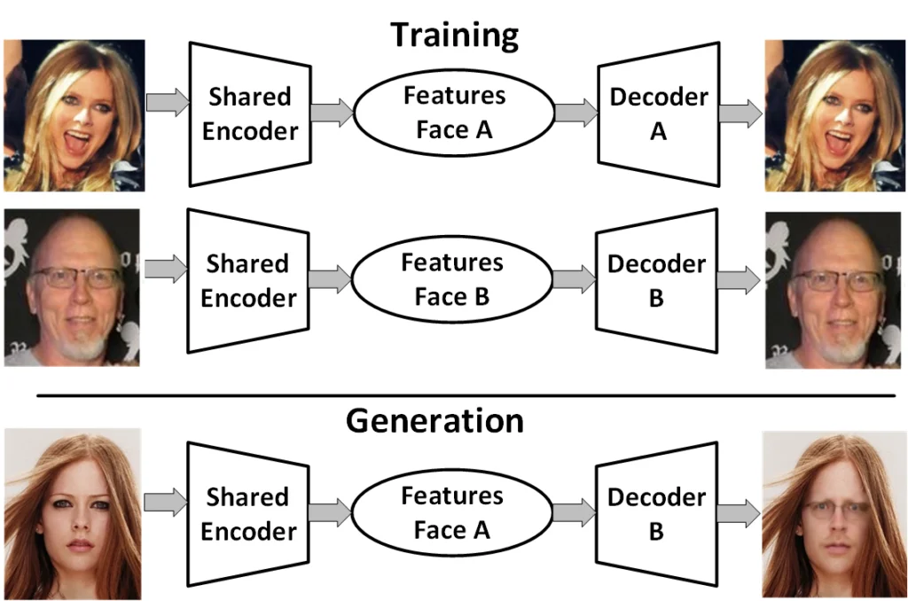

For a technical deep dive, see the [survey by Tolosana et al. (2020)](https://arxiv.org/abs/2004.11138).

## Real-world examples

**Political deepfakes:**

| Example | Impact |
| --- | --- |
| Obama PSA (2018) | [BuzzFeed/Jordan Peele demonstration](https://www.vox.com/2018/4/18/17252410/jordan-peele-obama-deepfake-buzzfeed) |
| Zelensky surrender video | [Attempted wartime deception](https://www.npr.org/2022/03/16/1087062648/deepfake-video-zelenskyy-experts-war-manipulation-ukraine-russia) |
| Indian election audio | [AI voice clones of politicians](https://www.bbc.com/news/world-asia-india-68918330) |

**Financial fraud:**

- [CEO voice clone authorised £200K transfer](https://www.dclsearch.com/blog/2019/09/ai-mimics-ceo-voice-to-scam-uk-energy-firm-out-of-ps200k)
- [Estimated $25 million scam in Hong Kong (2024)](https://www.cnn.com/2024/05/16/tech/arup-deepfake-scam-loss-hong-kong-intl-hnk)

**Non-consensual intimate imagery:**

- 96% of deepfakes online ([Sensity/Deeptrace, 2019](https://sensity.ai/reports/))
- Women overwhelmingly targeted: a tool for harassment and extortion
- 2024 update from [Home Security Heroes](https://www.securityhero.io/state-of-deepfakes/) put the share at 98%
- Legal response is lagging

[figure not shown]

Source: [NPR](https://www.npr.org/2022/03/16/1087062648/deepfake-video-zelenskyy-experts-war-manipulation-ukraine-russia)

The first big audit of deepfakes online ([Sensity, 2019](https://sensity.ai/reports/)) found that almost all of them were pornographic, and almost all targeted women.

## RAND’s primer on deepfakes

- Deepfakes are one tool among many
- “Cheap fakes” often just as effective ([Paris & Donovan, 2019](https://datasociety.net/library/deepfakes-and-cheap-fakes/) coined the term)
- Context matters more than technical quality
- Social vulnerability enables technical attacks

**The liar’s dividend:**

- When anything could be fake…
- Real evidence can be dismissed as fake
- “That video of me is a deepfake!”
- Truth becomes contested terrain

**RAND’s threat assessment:**

- Near-term: Targeted harassment, fraud
- Medium-term: Election manipulation
- Long-term: Erosion of shared reality

[figure not shown]

Source: [RAND Corporation](https://www.rand.org/pubs/perspectives/PEA1043-1.html)

Even if every deepfake were labelled tomorrow, the damage is done: people now doubt real video too. That is the liar’s dividend.

## The authenticity crisis

**[Chesney & Citron (2019)](https://www.foreignaffairs.com/articles/world/2018-12-11/deepfakes-and-new-disinformation-war):**

- Frame deepfakes as an epistemic threat: a danger to public knowledge itself, separate from privacy or fraud harms
- News loses the ability to verify its own sources
- Politicians get plausible deniability for everything caught on camera
- People retreat further into the views they already hold

**What the empirical work has found since:**

- [Vaccari & Chadwick (2020)](https://journals.sagepub.com/doi/10.1177/2056305120903408): UK survey (N=2,005) showed people are more uncertain after seeing deepfakes than directly deceived, and this lowers trust in news overall
- [Schiff, Schiff & Bueno (2024)](https://www.cambridge.org/core/journals/american-political-science-review/article/liars-dividend-can-politicians-claim-misinformation-to-evade-accountability/687FEE54DBD7ED0C96D72B26606AA073): five experiments, 15,000 Americans. False “deepfake!” claims help politicians dodge scandals, but mostly for text-based reporting, not video (so far)

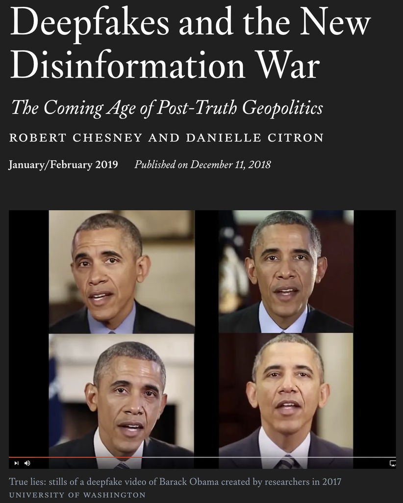

Source: [Chesney & Citron (2019)](https://www.foreignaffairs.com/articles/world/2018-12-11/deepfakes-and-new-disinformation-war)

## Discussion: what would convince you? 🤔

**Scenario:**

A video emerges of a political candidate you support saying something terrible. The candidate claims it’s a deepfake.

1. How would you decide if it’s real?
2. What evidence would convince you either way?
3. Does your political alignment affect your judgment?
4. What if experts disagree?

# Why we fall for it 🧠

## Are we hard-wired for fake news?

**The evolutionary angle:**

- Our brains evolved for small groups and immediate threats
- Novelty once meant survival-relevant information
- We still react to new, surprising claims the same way
- False news is almost by definition more novel than truth

**Why outrage spreads:**

- Threat detection is fast and automatic
- Emotionally charged content bypasses careful evaluation
- Fear and disgust trigger sharing behaviour
- We evolved to warn the group, not fact-check first

[figure not shown]

Source: [Soroka et al. (2019)](https://www.pnas.org/doi/abs/10.1073/pnas.1908369116)

## System 1 vs System 2

**[Kahneman’s (2011)](https://en.wikipedia.org/wiki/Thinking,_Fast_and_Slow) dual-process theory:**

|  | System 1 | System 2 |
| --- | --- | --- |
| Speed | Fast, automatic | Slow, deliberate |
| Effort | Effortless | Requires concentration |
| Mode | Intuitive, emotional | Analytical, logical |
| Default? | Yes | Only when triggered |

**Social media is a System 1 environment:**

- Infinite scroll rewards quick reactions
- You see a video, react, share, move on
- System 2 never kicks in unless something jolts you
- Deepfakes are designed to feel real at System 1 speed

**The problem:**

- Catching a fake requires System 2
- But strong emotion (outrage, fear) suppresses System 2
- [Pennycook & Rand (2019)](https://www.sciencedirect.com/science/article/abs/pii/S001002771830163X) tested this directly: people who score higher on cognitive reflection tests are better at spotting fake news, regardless of party

[figure not shown]

## Confirmation bias

**What it is:**

- We seek evidence that confirms what we already believe
- We dismiss evidence that contradicts it
- This isn’t laziness; it’s how brains manage information overload
- [Nickerson (1998)](https://doi.org/10.1037/1089-2680.2.2.175) called it the most pervasive bias in human reasoning

**How it works with deepfakes:**

- Who said it? If it’s someone we trust, we’re more likely to believe it, even if it’s fake (the opposite is also true)
- [Taber & Lodge (2006)](https://doi.org/10.1111/j.1540-5907.2006.00214.x): people argue back when corrected, sometimes hardening their position
- Corrections still feel like an attack on identity, even when they aren’t

[figure not shown]

Confirmation bias is not about intelligence. Educated people are sometimes better at rationalising bad evidence, because they have more tools to construct justifications.

## The bandwagon effect

**What [Asch (1956)](https://psycnet.apa.org/record/2011-16966-001) showed in the 1950s:**

- People will deny what their own eyes tell them if enough others disagree
- About 75% of participants conformed at least once on an obvious task
- [Bond & Smith (1996)](https://psycnet.apa.org/record/1996-01401-006) replicated Asch across 17 countries and confirmed the effect, though weaker in individualistic cultures

**On social media, numbers are social proof:**

- A video with 2 million views “must be real”
- We outsource our judgment to the crowd

**How this helps deepfakes spread:**

- Early shares create a snowball
- Each share adds perceived legitimacy
- By the time fact-checkers respond, millions have seen it
- Taking it down can actually increase belief (“they’re hiding something”)

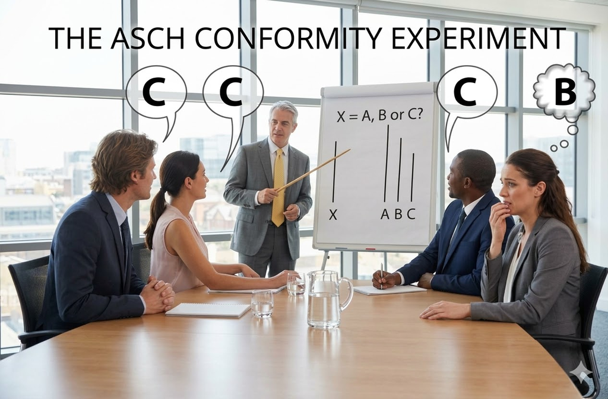

Asch’s experiments used lines on a card. Today, the same psychology plays out with deepfake videos shared millions of times.

## The “in the know” feeling

**Sharing as social currency:**

- Breaking news makes you feel like an insider
- “Did you see this?!” = status in your group
- Being first to share gets the attention

**Why this matters:**

- Creates a race to share before verifying
- People share content they haven’t fully read ([Gabielkov et al., 2016](https://inria.hal.science/hal-01281190): 59% of links shared on Twitter were never clicked)

**Combined with the other biases:**

- Confirmation bias picks *what* we share (things we agree with)
- The bandwagon effect picks *when* (once it’s already popular)
- The “in the know” feeling picks *how fast* (immediately, no checking)

[figure not shown]

Source: [Adam Grant](https://www.instagram.com/p/CoxwfquP3F7/)

We share what confirms our views *and* makes us look informed. The truth can wait; the dopamine hit can’t.

# Responses 🛡️

## Technical detection

**Detection approaches:**

| Method | How it works |
| --- | --- |
| Artefact detection | Unnatural blinking, lighting |
| Biological signals | Pulse, micro-expressions |
| Source forensics | Compression artefacts, metadata |
| AI vs AI | Train detectors on known fakes |

**Why it’s hard:**

- Detectors can be fooled
- Adversarial training improves generators
- Real-time detection is difficult
- Scale: Millions of images, few moderators
- [Groh et al. (2022)](https://www.pnas.org/doi/10.1073/pnas.2110013119) tested ordinary people against a state-of-the-art detector on 5,000 deepfakes: humans and the model made different mistakes, and combining them beat either alone

[figure not shown]

Source: [Kumar et al. (2025)](https://www.sciencedirect.com/science/article/abs/pii/S1566253525000661)

## Content provenance

**A new idea:**

- Instead of trying to catch fakes after the fact, verify the real thing at the source.
- The [C2PA standard](https://c2pa.org/) (Adobe, Microsoft, BBC, the New York Times and others) embeds a cryptographic signature when a camera takes a picture, then logs every edit
- Viewers can check the chain back to source, and unsigned content becomes the suspicious one

**Why it isn’t a fix on its own:**

- Needs near-universal adoption to be useful at all
- Legacy content has no provenance to attach
- Signatures can be stripped, screenshots wash them out
- Tracks creation, but doesn’t prevent it
- Real privacy concerns about tying every image to a device and identity

## Platform policies

**What platforms actually do:**

- [YouTube](https://support.google.com/youtube/answer/14328491) requires creators to label realistic AI-generated content
- [Meta](https://about.fb.com/news/2024/04/metas-approach-to-labeling-ai-generated-content-and-manipulated-media/) tags AI-generated images and video using C2PA
- [TikTok](https://newsroom.tiktok.com/en-us/partnering-with-our-industry-to-advance-ai-transparency-and-literacy) requires disclosure
- X has [rolled back](https://www.theguardian.com/technology/2023/sep/26/x-twitter-disinformation-rate-rises-elon-musk) most of its 2020 synthetic-media rules

**What happens when platforms remove content:**

- Moves to less moderated platforms
- Removal can increase distrust
- [Bak-Coleman et al. (2021)](https://www.pnas.org/doi/10.1073/pnas.2025764118) argue platforms function as a planetary-scale behavioural system and need the same crisis discipline as climate science
- Piecewise content rules cannot fix system-level effects

[figure not shown]

Source: [Vice - YouTube](https://youtu.be/cHGbWn6iwHw)

## Legal frameworks

**Emerging legislation:**

- **US**: [Texas SB 751](https://capitol.texas.gov/tlodocs/86R/billtext/html/SB00751F.htm) and similar [state laws](https://natlawreview.com/article/texas-did-it-first-texas-was-first-enact-state-legislation-use-deep-fakes-elections) target election deepfakes
- **EU**: [AI Act Article 50](https://artificialintelligenceact.eu/article/50/) requires deepfake disclosure
- **UK**: [Online Safety Act](https://www.gov.uk/government/news/government-crackdown-on-explicit-deepfakes) plus a 2025 amendment criminalising the creation of non-consensual sexual deepfakes
- **China**: [Deep Synthesis Provisions (2023)](https://www.loc.gov/item/global-legal-monitor/2023-04-25/china-provisions-on-deep-synthesis-technology-enter-into-effect/) require disclosure of AI-generated content

**Challenges:**

- Jurisdictional: creators can be anywhere
- Enforcement: finding perpetrators is hard
- Definition: what counts as a “deepfake”?
- Speech: satire, art, legitimate uses

[figure not shown]

Source: [Columbia Journal of Law and Arts](https://journals.library.columbia.edu/index.php/lawandarts/announcement/view/844)

**Where the legal scholarship lands:**

- [Chesney & Citron (2019)](https://papers.ssrn.com/sol3/papers.cfm?abstract_id=3213954): no single legal tool fits. Defamation is too slow, criminal law too narrow, and [Section 230](https://www.eff.org/issues/cda230) (the US law that shields platforms from liability for user content) too broad

## Media literacy

**What the evidence says works:**

- [Pennycook & Rand (2021)](https://www.nature.com/articles/s41586-021-03344-2): a small accuracy nudge before sharing improves the quality of news people pass along
- [Roozenbeek et al. (2022)](https://www.science.org/doi/10.1126/sciadv.abo6254): short inoculation videos teaching manipulation tactics. Tested on YouTube with 22,632 users, with measurable effects
- [Guess et al. (2020)](https://www.pnas.org/doi/10.1073/pnas.1920498117): media literacy tips improved discernment of false news by 26.5% in the US and 17.5% in India
- Effects are real but often [short-lived](https://onlinelibrary.wiley.com/doi/10.1111/jasp.13049) (Capewell et al., 2024). No single intervention scales to billions on its own

# Summary 📝

## Main takeaways

**Misinformation and AI**

- Misinformation is old; AI changes scale
- Attention economy amplifies false content
- Platform incentives work against truth

**Deepfakes**

- Synthetic media quality improving rapidly
- Political manipulation, NCII, fraud
- The “liar’s dividend” undermines all evidence

**Why we fall for it**

- Evolutionary wiring makes novelty irresistible
- System 1 scrolling, System 2 sleeping
- Confirmation bias is the vulnerability no patch can fix
- Bandwagon and “in the know” feeling accelerate sharing

**Responses**

- Detection: necessary, insufficient
- Provenance: promising, years away
- Legal: slow, jurisdictional
- Literacy: helps, doesn’t scale
- No single fix works; layering defences is the best we have

# … and that’s all for today! 🎉